# 2017-09-09-probability

#### 수식이 깨질 경우 새로고침을 눌러주세요.

## Probability for Data-Science-11

### 공분산과 상관계수

> 두 개 이상의 서로 연관성을 갖는 자료 값의 집합들이나 혹은 확률 변수들의 관계를 나타내는 값

> Heatmap과 같은 서술 통계 방법으로 묘사하거나 결합 확률 분포를 사용하여 정의한다.

#### 다변수 확률 변수도 단변수의 경우처럼 평균, 분산과 같은 대표값을 가질 수 있다.

- 그 중 가장 중요한 것이 자료 간의 상관 관계를 나타내는 공분산(covariance)과 상관계수(correlation coefficient)이다.

  > 공분산과 상관계수
  > > - 샘플 자료 집합에 대해 정의되는 샘플 공분산, 샘플 상관계수가 있다.
  > > - 확률 변수에 대해 정의되는 공분산, 상관계수가 있다.

### Covariance 공분산

> 이변량 확률변수일 경우 $$ \begin{eqnarray} \text{Cov}[X_1, X_2] &=& E[(X_1 - E[X_1])(X_2 - E[X_2])] \\ \\ &=& E[X_1X_2] - E[X_1]E[X_2] \end{eqnarray} $$

> 3개 이상의 랜덤 변수의 공분산은 다음과 같이 **Matrix 형태**로 표시하는 것이 좋다.

$$ X = \left[X_1, \cdots, X_K\right]^T \in R^K \;\;\; \text{where } \;\;\;X_1, \cdots, X_K \in R $$

> $$ \begin{eqnarray} \text{Cov}[X] &=& E\left[(X - E[X])(X - E[X])^T\right] \;\;\;\;\; ➡︎ * ⬇︎ 꼴로 \\ \\&=& \begin{bmatrix} \text{Var}[X_1] & \text{Cov}[X_1,X_2] & \cdots & \text{Cov}[X_1,X_K] \\ \text{Cov}[X_2, X_1] & \text{Var}[X_2] & \cdots & \text{Cov}[X_2,X_K] \\ \vdots & \vdots & \ddots & \vdots \\ \text{Cov}[X_K,X_1] & \text{Cov}[X_K,X_2] & \cdots & \text{Var}[X_K] \end{bmatrix} \end{eqnarray} $$

### Sample Covariance

> Feature Data Matrix를 사용하는 경우에는 transpose되어 있으므로 다음과 같이 Sample Covariance를 추정한다.

$$ X = \left[X_1, \cdots, X_N\right]^T \in R^{N \times K} \;\;\; \text{where } X_1, \cdots, X_N \in R^K $$$$ \bbox[7px, border:2px solid blue]{ \begin{eqnarray} s^2 &=& \dfrac{1}{N-1} (X - \bar{X})^T(X - \bar{X}) \end{eqnarray} } $$

#### Covariance Matrix, Sample Covariance Matrix는 대칭 행렬(Symmetric)

### 다음 예제를 살펴보자.

```python
# -*- coding: utf-8 -*-

import seaborn as sns
import pandas as pd
import scipy as sp
import matplotlib as mpl
import matplotlib.pylab as plt
import numpy as np
%matplotlib inline
sns.set()
sns.set_color_codes()
```

```python
# 가우시안 표준 정규 분포에서 1000 by 6 매트릭스 난수 생성
X = 10 * np.random.randn(1000, 6)
X
```

```
array([[  8.58043661,   4.71023024,   9.24774385,   9.34358593,
         -7.71831537,   2.37903155],
       [  3.88431169, -20.76823965,  -3.77346363,   1.38649368,
          4.39990465,  11.22322594],
       [-19.66959642,   1.84522825,  12.70075655,  19.18620366,
         -3.71250313,  -5.04677104],
       ...,
       [  5.53065299,   1.63813428,   5.8084065 ,  -8.32310388,
         -6.84716639,  11.23678943],
       [  0.38904726,  -5.83550845,  15.2993432 ,  -0.91669337,
        -18.57364371, -10.50049587],
       [  7.21621408,  -7.53461474,   3.28834859,  25.22893906,
         -2.26841842, -15.61527417]])
```

```python
# np.cov()는 defalut가 ↓↓↓↓ 이렇게 쌓음, np.cov(X, rowvar=0) ⇶ 이렇게 쌓음
C = np.cov(X, rowvar=0)
C
```

```
array([[ 101.7303638 ,   -3.52397906,   -1.78898597,    3.58656921,
          -3.54885923,    2.69802591],
       [  -3.52397906,  102.16394783,   -1.16472425,    0.3528889 ,
           1.27050927,    1.12335031],
       [  -1.78898597,   -1.16472425,   92.6490006 ,    1.89122781,
          -5.52135689,   -4.4121152 ],
       [   3.58656921,    0.3528889 ,    1.89122781,  101.4877062 ,
          -1.92396254,   -1.30537126],
       [  -3.54885923,    1.27050927,   -5.52135689,   -1.92396254,
         103.81986832,   -3.59423079],
       [   2.69802591,    1.12335031,   -4.4121152 ,   -1.30537126,
          -3.59423079,  103.07785639]])
```

```python
(X - X.mean()).T.dot((X - X.mean()))/(len(X)-1)
```

```
array([[ 102.09321294,   -3.60224186,   -2.18264016,    3.68014813,
          -3.40393382,    2.56858943],
       [  -3.60224186,  102.1808283 ,   -1.07981712,    0.3327049 ,
           1.23925036,    1.15126842],
       [  -2.18264016,   -1.07981712,   93.0760751 ,    1.78970427,
          -5.67858614,   -4.27168986],
       [   3.68014813,    0.3327049 ,    1.78970427,  101.51184023,
          -1.88658623,   -1.33875297],
       [  -3.40393382,    1.23925036,   -5.67858614,   -1.88658623,
         103.87775291,   -3.64592896],
       [   2.56858943,    1.15126842,   -4.27168986,   -1.33875297,
          -3.64592896,  103.1240293 ]])
```

> 1. np.cov(X, rowvar=0) 으로 방법
> 2. 수식을 구현해서 구하는 방법

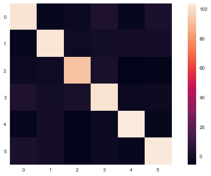

```python
plt.figure(figsize=(12,6))
plt.imshow(C, interpolation="none")

# colorbar() → 0 ~ 100까지의 값으로 변환
plt.colorbar()
plt.grid(False)
```

### Correlation 상관도

- 두 확률변수(X1, X2)의 선형 상관관계를 나타내는 척도 (Pearson Correlation)

$$ \begin{eqnarray} \text{Cor}[X_1, X_2] &=& \rho_{1,2} \\ \\ &=& \dfrac{\text{Cov}[X_1, X_2]}{\sqrt{\text{Var}[X_1]\text{Var}[X_2]}} \\ \\ &=& \dfrac{\text{Cov}[X_1, X_2]}{\rho{1}\cdot \rho{2}} \end{eqnarray} $$

$$ 상관계수 \;\; \rho는 \;\; (rho)라고 읽는다. $$

- Correlation Matrix
  - for $X_1$, $X_2$, $\cdots$, $X_N$

$$ \begin{eqnarray} R = \begin{bmatrix} 1 & \text{Cor}[X_1,X_2] & \cdots & \text{Cor}[X_1,X_N] \\ \text{Cor}[X_2, X_1] & 1 & \cdots & \text{Cor}[X_2,X_N] \\ \vdots & \vdots & \ddots & \vdots \\ \text{Cor}[X_N, X_1] & \text{Cor}[X_N,X_2] & \cdots & 1 \end{bmatrix} \end{eqnarray} $$

```python
# rowvar=0, ⇶ 이렇게 쌓음(행으로 쌓기)
R = np.corrcoef(X, rowvar=0)
R
```

```
array([[ 1.        , -0.0345668 , -0.01842728,  0.03529776, -0.03453212,
         0.02634742],
       [-0.0345668 ,  1.        , -0.01197165,  0.00346563,  0.01233641,
         0.01094671],
       [-0.01842728, -0.01197165,  1.        ,  0.01950369, -0.056297  ,
        -0.04514855],
       [ 0.03529776,  0.00346563,  0.01950369,  1.        , -0.01874346,
        -0.01276276],
       [-0.03453212,  0.01233641, -0.056297  , -0.01874346,  1.        ,
        -0.03474426],
       [ 0.02634742,  0.01094671, -0.04514855, -0.01276276, -0.03474426,
         1.        ]])
```

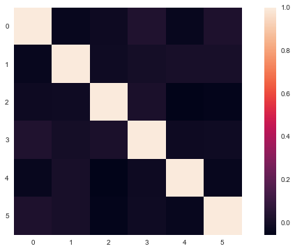

```python
plt.figure(figsize=(12,6))

plt.imshow(R, interpolation="none")
plt.colorbar() # 0 ~ 1의 값
plt.grid(False)
```

- ρ = 1 : 완전 선형 상관 관계
- ρ = 0 : 무상관 (독립과는 다름)
- ρ = −1 : 완전 선형 반상관 관계

#### 서로 독립이면 → correlation = 0 (True) (얘만 참!!)

#### 서로 독립이면 ← correlation = 0 (False)

> 충분 조건이다.

$$ -1 \leq \rho \leq 1 $$

[figure not shown]

> - 기울기는 중요하지 않다. 선형성을 갖는지가 중요하다.
> - 상관계수 = 0 이지만, 독립이 아닌 경우가 있다.

>   > 원 방정식 꼴 $$ x^2 + y^2 = r^2 $$

### 다음은 상관계수가 동일한 자료이다. 서로를 비교해 보자.

```python
import statsmodels.api as sm
data = sm.datasets.get_rdataset("anscombe")
df = data.data
df
```

|  | x1 | x2 | x3 | x4 | y1 | y2 | y3 | y4 |
| --- | --- | --- | --- | --- | --- | --- | --- | --- |
| 0 | 10 | 10 | 10 | 8 | 8.04 | 9.14 | 7.46 | 6.58 |
| 1 | 8 | 8 | 8 | 8 | 6.95 | 8.14 | 6.77 | 5.76 |
| 2 | 13 | 13 | 13 | 8 | 7.58 | 8.74 | 12.74 | 7.71 |
| 3 | 9 | 9 | 9 | 8 | 8.81 | 8.77 | 7.11 | 8.84 |
| 4 | 11 | 11 | 11 | 8 | 8.33 | 9.26 | 7.81 | 8.47 |
| 5 | 14 | 14 | 14 | 8 | 9.96 | 8.10 | 8.84 | 7.04 |
| 6 | 6 | 6 | 6 | 8 | 7.24 | 6.13 | 6.08 | 5.25 |
| 7 | 4 | 4 | 4 | 19 | 4.26 | 3.10 | 5.39 | 12.50 |
| 8 | 12 | 12 | 12 | 8 | 10.84 | 9.13 | 8.15 | 5.56 |
| 9 | 7 | 7 | 7 | 8 | 4.82 | 7.26 | 6.42 | 7.91 |
| 10 | 5 | 5 | 5 | 8 | 5.68 | 4.74 | 5.73 | 6.89 |

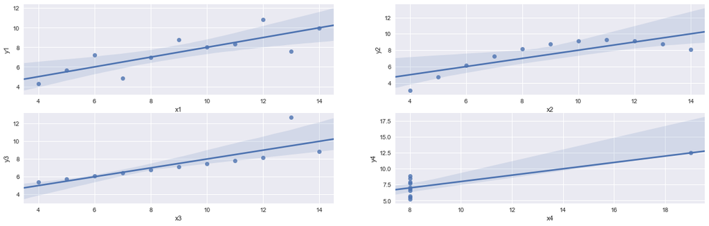

```python
plt.figure(figsize=(20,6))
plt.subplot(221)
sns.regplot(x="x1", y="y1", data=df)
plt.subplot(222)
sns.regplot(x="x2", y="y2", data=df)
plt.subplot(223)
sns.regplot(x="x3", y="y3", data=df)
plt.subplot(224)
sns.regplot(x="x4", y="y4", data=df)
plt.show()
```

> 3은 이상치 하나가 rho의 값을 떨어뜨렸다. 이상치를 제거하면 거의 선형에 가깝다.

> 4는 자료 자체가 서로 무관하다.(X,Y) 이상치 하나가 상관계수를 1에 가깝게 만들었다.

```
[[  1.00000000e+00   2.37884753e-16]
 [  2.37884753e-16   1.00000000e+00]]
```

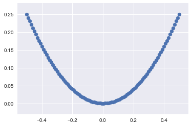

```python
x = np.linspace(-0.5, .5, 100)
y = x**2
print(np.corrcoef(x, y))
plt.scatter(x, y)
```

#### 위와 같은 분포는 비선형처리를 한다.

### Rank-Based Correlation

> **Categorical 값인 경우 사용**
- Spearman’s rank correlation coefficient
  > - 두 변수를 순위(rank)로 변환한 후에 순위에 대해 Pearson Correlation을 구함
  > - 비선형함수라도 단조함수(monotonic function)이면 상관관계 계산 가능
- Kendall tau rank correlation coefficient

  > 두 변수를 순위(rank)로 변환한 후에 두 변수의 순위가 같은 짝 concordant의 수를 이용하여 계산

$$ τ = \dfrac{\text{(number of concordant pairs) − (number of discordant pairs)}}{\dfrac{1}{2}n(n − 1)} $$

#### 다음 x, y는 유전자 배열이다.

```python
x = "TGGAGGCAATGGCGGCCAGCA"
y = "TGAGGGCCGGCGAGAATGGCA"

## {'A': 0, 'C': 3, 'G': 2, 'T': 1}의 딕셔너리를 만들어라.
mapping = dict(zip(['A', 'T', 'G', 'C'], range(4)))

## x와 y의 원소를 숫자 리스트로 만들어라.
x = [mapping[i] for i in x]
y = [mapping[i] for i in y]

# 스피어만의 순위 상관계수
sp.stats.spearmanr(x, y)
```

```
SpearmanrResult(correlation=-0.077861738747956322, pvalue=0.73727156297630891)
```

```python
# 켄달 토우의 순위 상관계수
sp.stats.kendalltau(x, y)
```

```
KendalltauResult(correlation=-0.066454351902408337, pvalue=0.73050316204856025)
```